# 신경망 기초 수학

```python
import math
import numpy as np
import matplotlib.pyplot as plt
plt.style.use(['seaborn-whitegrid'])
```

## 일차함수

- $y = ax + b$
  - $a$: 기울기, $b$: y절편
- 그래프 상에서 직선인 그래프(linear)

```python
def linear_function(x):
  a = 0.5
  b = 2

  return a*x + b
```

```python
print(linear_function(5))
```

```
4.5
```

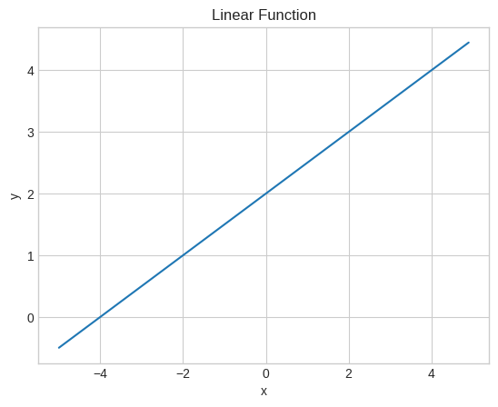

```python
x = np.arange(-5, 5, 0.1)
y = linear_function(x)

plt.plot(x, y)
plt.xlabel('x')
plt.ylabel('y')
plt.title('Linear Function')
plt.show()
```

## 이차함수

- $y = ax^2 + bx + c$
- 일반적으로 두 개의 실근을 가짐

```python
def quadratic_function(x):
  a = 1
  b = -1
  c = -2

  return (a*x**2 + b * x + c)
```

```python
print(quadratic_function(2))
```

```
0
```

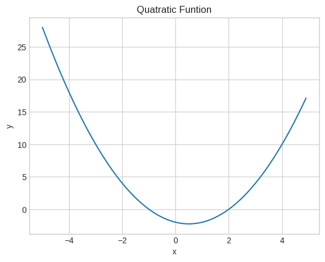

```python
x = np.arange(-5, 5, 0.1)
y = quadratic_function(x)

plt.plot(x, y)
plt.xlabel('x')
plt.ylabel('y')
plt.title('Quatratic Funtion')
plt.show()
```

## 삼차함수(다항함수)

- $y = ax^3 + bx^2 + cx + d$

```python
def cubic_function(x):
  a = 4
  b = 0
  c = -1
  d = -8

  return (a*x**3 + b*x**2 + c*x + d)
```

```python
print(cubic_function(3))
```

```
97
```

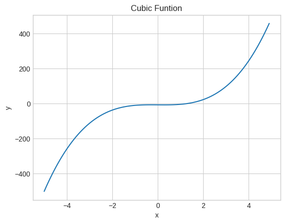

```python
x = np.arange(-5, 5, 0.1)
y = cubic_function(x)

plt.plot(x, y)
plt.xlabel('x')
plt.ylabel('y')
plt.title('Cubic Funtion')
plt.show()
```

### 함수의 최소값/최대값

```python
def my_func(x):
  a = 1
  b = -3
  c = 10
  return (a*x**2 + b*x + c)
```

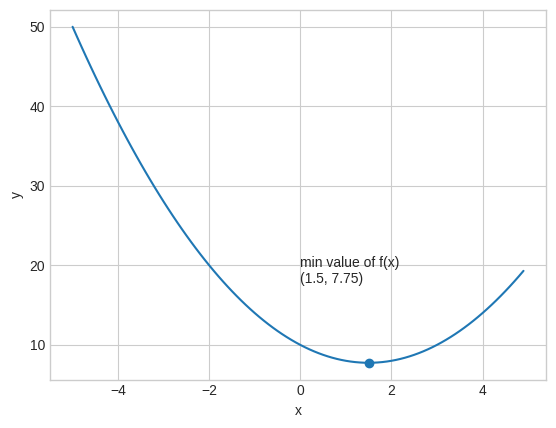

```python
x = np.arange(-5, 5, 0.1)
y = my_func(x)

plt.plot(x, y)
plt.xlabel('x')
plt.ylabel('y')
plt.scatter(1.5, my_func(1.5))
plt.text(1.5 - 1.5, my_func(1.5) + 10, 'min value of f(x)\n({}, {})'.format(1.5, my_func(1.5)), fontsize=10)
plt.show()
```

```python
min_val = min(y)
print(min_val)
```

```
7.75
```

### 특정 구간 내에서 최소값 구하기

```python
def get_minimum(x1, x2, f):
  x = np.arange(x1, x2, 0.01)
  y = f(x)

  plt.plot(x, y)
  plt.xlabel('x')
  plt.ylabel('y')
  plt.title('get_minimum')
  plt.show()

  return(min(y))
```

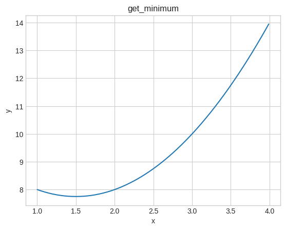

```
7.75
```

```python
print(get_minimum(1, 4, my_func))
```

## 지수함수 / 로그함수

- 지수함수-로그함수는 역함수 관계 ($y=x$ 직선 대칭 단, 밑이 같을 때)
- 파이썬으로 직접 구현 가능

## 지수함수

- $y = a^x$ ($a \ne 0$) (기본형)
- $y = e^x$ ($e = 2.71828...$)

```python
def exponential_function(x):
  a = 4
  return a**x
```

```python
print(exponential_function(4))
print(exponential_function(0))
```

```
256
1
```

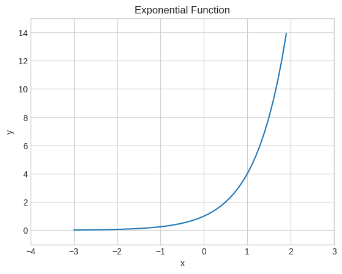

```python
x = np.arange(-3, 2, 0.1)
y = exponential_function(x)

plt.plot(x, y)
plt.xlabel('x')
plt.ylabel('y')
plt.ylim(-1, 15)
plt.xlim(-4, 3)
plt.title('Exponential Function')
plt.show()
```

```python
def exponential_function2(x):
  a = 4
  return math.pow(a, x)
```

```python
print(exponential_function2(4))
```

```
256.0
```

### 밑이 $e$인 지수함수 표현

- `math.exp(x)`
- `np,exp(x)`

```python
print(math.exp(4))
print(np.exp(4))
```

```
54.598150033144236
54.598150033144236
```

### 로그함수

[figure not shown]

```python
print(math.log(2, 3))
print(np.log2(4))
print(np.log(4))
```

```
0.6309297535714574
2.0
1.3862943611198906
```

### 역함수 관계

- $y=x$ 대칭

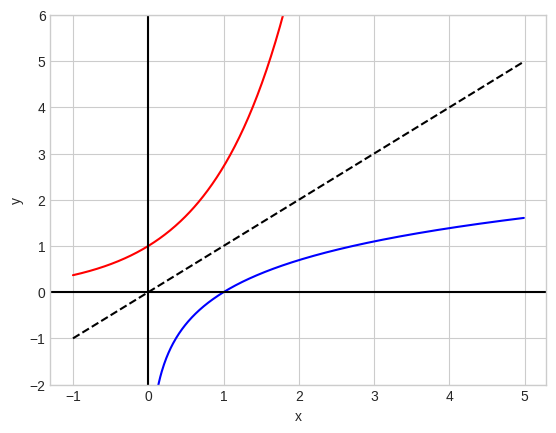

```python
x = np.arange(-1, 5, 0.01)
y1 = np.exp(x)

x2 = np.arange(0.000001, 5, 0.01)
y2 = np.log(x2)

y3 = x

plt.plot(x, y1, 'r-', x2, y2, 'b-', x, y3, 'k--')

plt.ylim(-2, 6)
plt.axvline(x=0, color='k')
plt.axhline(y=0, color='k')

plt.ylabel('y')
plt.xlabel('x')
plt.show()
```

### 함수 조작

- $y = -log_a(x)$와 $y = -log_a(1-x)$  
  x=0.5 대칭
- Logistic Regression을 위한 함수

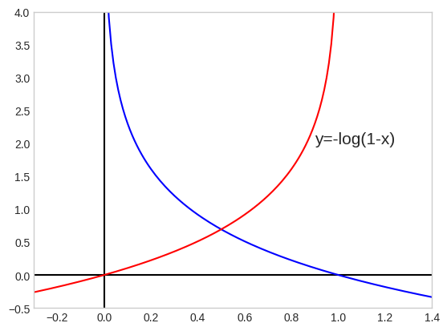

```python
x = np.arange(-10, 10, 0.01)
y1 = -np.log(x)
y2 = -np.log(1-x)

plt.axvline(x=0, color='k')
plt.axhline(y=0, color='k')

plt.grid()
plt.plot(x, y1, 'b-', x, y2, 'r-')
plt.text(0.9, 2.0, 'y=-log(1-x)', fontsize=15)
plt.xlim(-0.3, 1.4)
plt.ylim(-0.5, 4)
plt.scatter(0,5, -np.log(0.5))
plt.show()
```

## 극한

- 극한에 대해서는 어떠한 식을 코드로 표현할 수 있다 정도로만 이해하며 참고
- 극한에서 알아야 사실은 x가 어떤 값 a에 가까이 다가갈 때 a에 '한없이 가까이 간다'일 뿐, a에 도달하지 않는다는 점
- 이를 표현할 때, 엡실론(epsilon)이라는 아주 작은 값(ex, 0.0001) 등으로 표현

```python
from sympy import *
init_printing()

x, y, z = symbols('x y x')
a, b, c, t = symbols('a b c t')
```

- $\lim_{x \to 1} \left(\frac{x^3-1}{x-1} \right) = 3$

```
극한값: 3
```

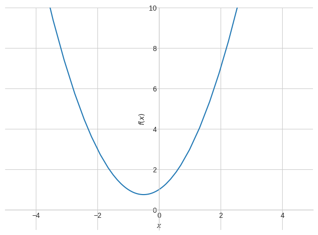

```python
print("극한값:", limit((x**3-1) / (x-1), x, 1))

plot( ((x**3-1) / (x-1)), xlim=(-5, 5), ylim=(-1, 10) );
```

- $\lim_{x \to \infty} \left(\frac{1+x}{x} \right)$

```
극한값: 1
```

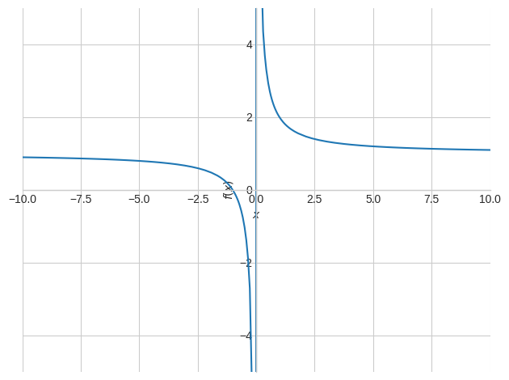

```python
print("극한값:", limit((1+x) / x, x, oo))

plot( (1+x) / x, xlim=(-10, 10), ylim=(-5, 5) );
```

- $\lim_{x \to 1}\frac{\sqrt{x+3}-2}{x-1} = \frac {1}{4}$

```
극한값: 1/4
```

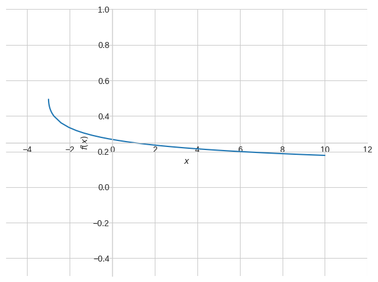

```python
print("극한값:", limit( (sqrt(x+3)-2) / (x-1), x, 1))

plot( (sqrt(x+3)-2) / (x-1), xlim=(-5, 12), ylim=(-0.5, 1) );
```

### 삼각함수의 극한

- $\lim_{x \to \frac{\pi}{2} +0}\ \tan x = -\infty$
- $\lim_{x \to \frac{\pi}{2} -0}\ \tan x = \infty$

```
극한값: -oo
극한값: oo
```

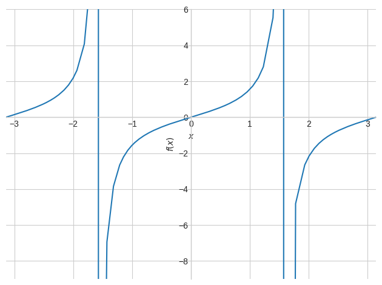

```python
print("극한값:", limit( tan(x), x, pi/2, '+'))
print("극한값:", limit( tan(x), x, pi/2, '-'))

plot(tan(x), xlim=(-3.14, 3.14), ylim=(-9, 6))
plt.show()
```

- $\lim_{x \to 0} \left(\frac{\sin x}{x} \right) = 1$

```
극한값: 1
```

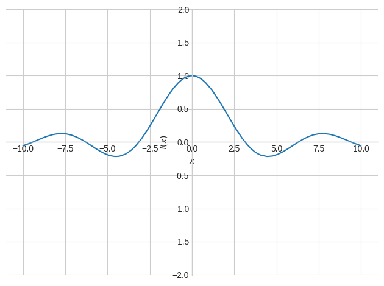

```python
print("극한값:", limit( sin(x)/x, x, 0))

plot(sin(x)/x, ylim=(-2, 2))
plt.show()
```

- $\lim_{x \to 0} x \sin \left(\frac{1}{x} \right)$

```
극한값: 0
```

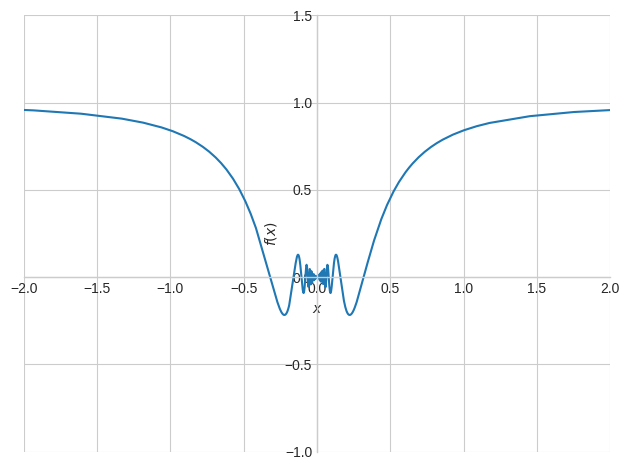

```python
print("극한값:", limit( x*sin(1/x), x, 0))

plot(x*sin(1/x), xlim=(-2, 2), ylim=(-1, 1.5))
plt.show()
```

### 지수함수, 로그함수의 극한

- $\lim_{x \to \infty} \left( \frac{2^x - 2^{-x}}{2^x + 2^{-x}} \right)$

```
극한값: 1
```

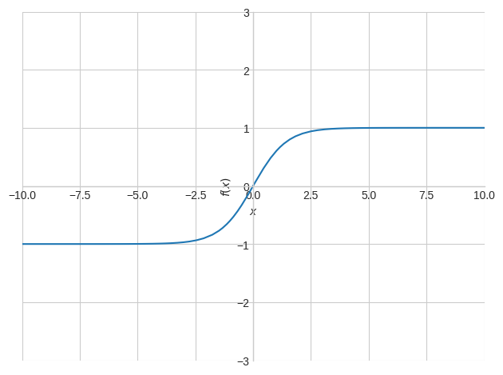

```python
print("극한값:", limit( (2**x - 2**(-x)) / (2**x + 2**(-x)), x, oo))

plot((2**x - 2**(-x)) / (2**x + 2**(-x)), xlim=(-10, 10), ylim=(-3, 3))
plt.show()
```

- $lim_{x \to \infty} \left (\ log_2(x+1) - log_2(x) \ \right) = 0$

```
극한값: 0
```

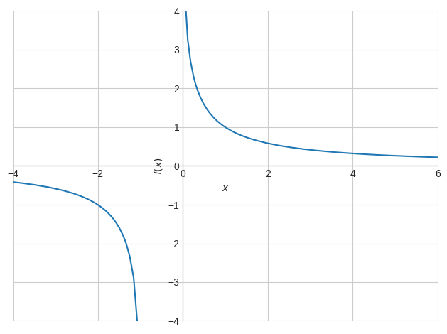

```python
print("극한값:", limit( log(x+1, 2) - log(x, 2), x, oo))

plot(log(x+1, 2) - log(x, 2), xlim=(-4, 6), ylim=(-4, 4))
plt.show()
```

### 자연로그(e)의 밑

(1) $lim_{x \to \infty} \ (1 + \frac{1}{x})^x \ = e$  
(2) $\lim_{x \to \infty} \ (1 + \frac{2}{x}^x) \ = e^2$  
(3) $\lim_{x \to 0} \ \frac{(e^x - 1)}{x} = 1$  
(4) $\lim_{x \to 0} \ \frac{ln(1 + x)}{x} = 1$

```
(1): E
(2): exp(2)
(3): 1
(4): 1
```

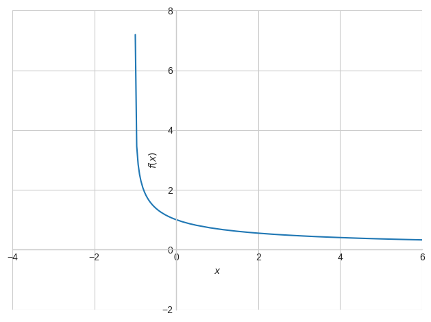

```python
print("(1):", limit( (1+1/x)**x, x, oo))
print("(2):", limit( (1+2/x)**x, x, oo))
print("(3):", limit( (exp(x)-1) / x, x, 0))
print("(4):", limit( (ln(1+x) / x), x, 0))

plot( ln(1+x)/x, xlim=(-4, 6), ylim=(-2,8) );
plt.show()
```

## 미분

- 어떤 한 순간의 변화량을 표시한 것

### 미분과 기울기

- 어떤 함수를 나타내는 그래프에서 한 점의 미분값(미분계수)를 구하는 것은 해당 점에서의 접선을 의미

[figure not shown]

<sub>출처: https://ko.wikipedia.org/wiki/%EB%AF%B8%EB%B6%84</sub>

- 기울기는 **방향성**을 가짐
  - 이용할 미분 식 (수치 미분)  
    $\frac{df(x)}{dx} = \lim_{x \to \infty} \frac{f(x+h) - f(x-h)}{2h}$
- [주의] $ \ h \ $는 아주 작은 수를 뜻하는데, 예를 들어 $\ 10e-50 \ $ 정도의 수를 하면 파이썬은 이를 $0.0$으로 인식
- 따라서, 딥러닝에서 아주 작은 수를 정할 때 $\ 1e-4\ $ 정도로 설정해도 무방

```python
def numerical_diffrential(f, x):
  h = 1e-4
  return(f(x+h)-f(x-h))/(2*h)
```

### 함수 위의 점 $(a, b)$에서의 접선의 방정식

- 예제 : 점 (1, 7) 에서의 기울기

```python
def my_func(x):
  return (2*x**2+3*x+2)
```

```python
def linear_func(a, b, c, x):
  return (c*(x-a)+b)
```

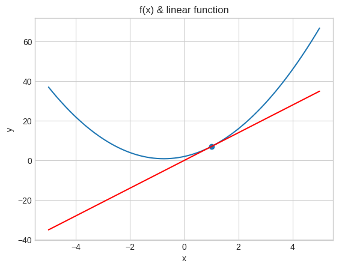

```python
c = numerical_diffrential(my_func, 1)

x = np.arange(-5, 5, 0.01)
y = linear_func(1, my_func(1), c, x)

plt.xlabel('x')
plt.ylabel('y')
plt.scatter(1, my_func(1))
plt.plot(x, my_func(x), x, y, 'r-')
plt.title('f(x) & linear function')
plt.show()
```

### 미분 공식

- $\frac{d}{dx} (c) = 0\ (c는 상수)$
- $\frac{d}{dx} [cf(x)] = cf^\prime (x)$
- $\frac{d}{dx} [f(x) + g(x)] = f^\prime(x) + g^\prime(x)$
- $\frac{d}{dx} [f(x)-g(x)] = f^\prime(x)\ - \ g^\prime(x)$
- $\frac{d}{dx} [f(x)g(x)] = f(x)g^\prime(x)\ + \ f^\prime(x)g(x)\ (곱셈공식)$
- $\frac{d}{dx} [\frac{f(x)}{g(x)}] = \frac{g(x)f^\prime(x)\ - \ f(x)g^\prime(x)}{[g(x)]^2}$
- $\frac{d}{dx} [x^n] = nx^n-1$

### 편미분

- 변수가 1개짜리인 위의 수치미분과 달리, 변수가 2개 이상일 때의 미분법을 편미분이라 함
- 다변수 함수에서 특정 변수를 제외한 나머지 변수는 상수로 처리하여 미분을 하는 것
- 각 변수에 대해 미분 표시를 $\sigma$를 통해 나타남
- ex) $f(x_0, x_1) = x_0^2 + x_1^2$

```python
def my_func2(x):
  return(x[0]**2 + x[1]**2)
```

- 예제1 : x0에 대한 편미분, $\frac{\sigma f}{\sigma x_0}$

```python
x = np.array([1, 2])

def f0_function(x0):
  return(x0**2) + (2**2)

print(numerical_diffrential(f0_function, x[0]))
```

```
1.9999999999997797
```

- 예제2 : x1에 대한 편미분, $\frac{\sigma f}{\sigma x_1}$

```python
def f1_function(x1):
  return (1**2) + (x1**2)

print(numerical_diffrential(f1_function, x[1]))
```

```
4.000000000004
```

### 기울기(gradient)

- 방향성을 가짐

```python
def numerical_diff(f, x):
  h = 1e-5
  grad = np.zeros_like(x)

  for i in range(x.size):
    tmp = x[i]

    x[i] = tmp + h
    fxh1 = f(x)

    x[i] = tmp - h
    fxh2 = f(x)

    grad[i] = (fxh1 - fxh2) / (2*h)
    x[i] = tmp

  return grad
```

```python
print(numerical_diff(my_func2, np.array([3.0, 4.0])))
print(numerical_diff(my_func2, np.array([1.0, 2.0])))
```

```
[6. 8.]
[2. 4.]
```

### 기울기의 의미를 그래프로 확인

- 기울기가 가장 낮은 장소(가운데)로부터 거리가 멀어질수록 기울기가 커짐
- 기울기가 커진다는 것은 영향을 많이 받는다는 의미
- 기울기가 작다는 것은 영향을 적게 받는다는 의미

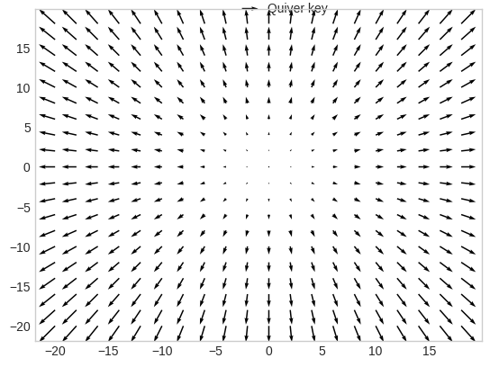

```python
X = np.arange(-20, 20, 2)
Y = np.arange(-20, 20, 2)
U, V = np.meshgrid(X, Y)

fig, ax = plt.subplots()
q = ax.quiver(X, Y, U, V)
ax.quiverkey(q, X=0.5, Y=1.0, U=20, label='Quiver key', labelpos='E')
plt.grid()
plt.show()
```